# Albacore Diet Synthesis C Trait Modelling

Natasha Hardy

15/04/2021

# Trait variation in albacore diet across geographies

## Current work

Troubleshoot following analysis: BM suggested (email from 3/06/2020): You might also see differences between upwelling systems (e.g. California Current, Canary Current) vs. downwelling systems (e.g. Agulhas Current, both coasts of Australia), but that should also fall out in the ocean basin analysis, given the sample distribution

## Data needs

For Ocean Basin analysis:

- Species (L): alb_prey_pa_use ==> “./data/output_data/alb_prey_pa_use.csv”
- Env/Site (R): alb_covars_use ==> “./data/output_data/alb_covars_use.csv”
- Traits (Q): alb_trait_use ==> “./data/output_data/alb_trait_use.csv”

Can also use either of the above for life stage of predator assessment + report results to Desiree.

## Load DFs for analyses

```r
#L - species df
alb_prey_pa_use = read.csv(here::here("./data/2_output_data/alb_prey_pa_use.csv"))
dim(alb_prey_pa_use)
```

```
## [1] 57 98
```

```r
#R - covars df
alb_covars_use = read.csv(here::here("./data/2_output_data/alb_covars_use.csv"))

#As factors
alb_covars_use[,1:ncol(alb_covars_use)] =  lapply(alb_covars_use[,1:ncol(alb_covars_use)], as.factor)
```

```r
#Q - trait df
alb_trait_use = read.csv(here::here("./data/2_output_data/alb_trait_use.csv"))

#Needs species as rows
#Assign speces as rownames
rownames(alb_trait_use) <- alb_trait_use$prey_sp
#Order species list if needed
alb_trait_use <- alb_trait_use[ order(row.names(alb_trait_use)), ]
#Traits as factors for analyses
alb_trait_use[,1:ncol(alb_trait_use)] =  lapply(alb_trait_use[,1:ncol(alb_trait_use)], as.factor)

dim(alb_trait_use)
```

```
## [1] 98  9
```

## DF Checks

**Covars**

```r
#Summary stats on covars
unique(alb_covars_use$StudyID) #22 studies
unique(alb_covars_use$OceanBasin) #3 Ocean basins
```

## DF manips for multivariate analyses

```r
## Make sure species names match abund matrix
rownames(alb_trait_use) == colnames(alb_prey_pa_use) #awesome!
```

```
##  [1] TRUE TRUE TRUE TRUE TRUE TRUE TRUE TRUE TRUE TRUE TRUE TRUE TRUE TRUE TRUE
## [16] TRUE TRUE TRUE TRUE TRUE TRUE TRUE TRUE TRUE TRUE TRUE TRUE TRUE TRUE TRUE
## [31] TRUE TRUE TRUE TRUE TRUE TRUE TRUE TRUE TRUE TRUE TRUE TRUE TRUE TRUE TRUE
## [46] TRUE TRUE TRUE TRUE TRUE TRUE TRUE TRUE TRUE TRUE TRUE TRUE TRUE TRUE TRUE
## [61] TRUE TRUE TRUE TRUE TRUE TRUE TRUE TRUE TRUE TRUE TRUE TRUE TRUE TRUE TRUE
## [76] TRUE TRUE TRUE TRUE TRUE TRUE TRUE TRUE TRUE TRUE TRUE TRUE TRUE TRUE TRUE
## [91] TRUE TRUE TRUE TRUE TRUE TRUE TRUE TRUE
```

```r
# Then create the mvabund matrix
alb_prey_pa_use_mv = as.mvabund(alb_prey_pa_use)

#Check again that species names match trait values
rownames(alb_trait_use) == colnames(alb_prey_pa_use_mv) #awesome!
```

```
##  [1] TRUE TRUE TRUE TRUE TRUE TRUE TRUE TRUE TRUE TRUE TRUE TRUE TRUE TRUE TRUE
## [16] TRUE TRUE TRUE TRUE TRUE TRUE TRUE TRUE TRUE TRUE TRUE TRUE TRUE TRUE TRUE
## [31] TRUE TRUE TRUE TRUE TRUE TRUE TRUE TRUE TRUE TRUE TRUE TRUE TRUE TRUE TRUE
## [46] TRUE TRUE TRUE TRUE TRUE TRUE TRUE TRUE TRUE TRUE TRUE TRUE TRUE TRUE TRUE
## [61] TRUE TRUE TRUE TRUE TRUE TRUE TRUE TRUE TRUE TRUE TRUE TRUE TRUE TRUE TRUE
## [76] TRUE TRUE TRUE TRUE TRUE TRUE TRUE TRUE TRUE TRUE TRUE TRUE TRUE TRUE TRUE
## [91] TRUE TRUE TRUE TRUE TRUE TRUE TRUE TRUE
```

```r
#Check all matrix dimensions
dim(alb_trait_use) #good
```

```
## [1] 98  9
```

```r
dim(alb_prey_pa_use_mv) #good
```

```
## [1] 57 98
```

```r
dim(alb_covars_use) #good
```

```
## [1] 57  9
```

```r
#Traits - select and manipulate that df - ideally we want to use the same df here
traits_use = alb_trait_use[,c(4:7,9)] %>%
  dplyr::rename(cluster = prob.clust.num)

str(traits_use)
```

```
## 'data.frame':    98 obs. of  5 variables:
##  $ vert_habitat    : Factor w/ 3 levels "demersal","epipelagic",..: 2 3 2 2 1 3 3 2 3 1 ...
##  $ horz_habitat    : Factor w/ 3 levels "coastal","continental shelf",..: 3 3 1 2 2 3 3 3 3 2 ...
##  $ diel_migrant_cat: Factor w/ 2 levels "diel (no)","diel (yes)": 2 2 2 2 2 2 2 1 2 2 ...
##  $ season_cat      : Factor w/ 2 levels "season (no)",..: 2 2 1 2 2 2 2 2 2 2 ...
##  $ cluster         : Factor w/ 7 levels "1","2","3","4",..: 5 2 7 6 6 2 2 3 2 6 ...
```

## TRAIT GLMS - MANYGLMS

### Read in models

```r
#Manyglm
ocean_spp = readRDS(here::here("outputs_figures/5_traitglms/ocean_models_PA/ocean_spp.rds"))
ocean_clusters_many = readRDS(here::here("outputs_figures/5_traitglms/ocean_models_PA/ocean_clusters_many.rds"))
ocean_trait_many = readRDS(here::here("outputs_figures/5_traitglms/ocean_models_PA/ocean_traits_many.rds"))
ocean_full_spp_many = readRDS(here::here("outputs_figures/5_traitglms/ocean_models_PA/ocean_full_spp_many.rds"))

#Anovas
an_ocean_spp = readRDS(here::here("outputs_figures/5_traitglms/ocean_models_PA/ocean_spp_anova.rds"))
an_ocean_clusters_many = readRDS(here::here("outputs_figures/5_traitglms/ocean_models_PA/ocean_clusters_many_anova.rds"))
an_ocean_trait_many = readRDS(here::here("outputs_figures/5_traitglms/ocean_models_PA/ocean_traits_many_anova.rds"))
an_ocean_full_spp = readRDS(here::here("outputs_figures/5_traitglms/ocean_models_PA/ocean_full_spp_many_anova.rds"))
```

### Species model

**SPP Manyglm - Ocean Basin**

```r
ocean_spp <- traitglm(L = alb_prey_pa_use_mv,
                      R = alb_covars_use$OceanBasin,
                      family = binomial(link = "logit")#,
                      #composition = TRUE #note that col.intercepts = TRUE is the default
                      ) #note default is "manyglm"
ocean_spp
saveRDS(ocean_spp, file = here::here("outputs_figures/5_traitglms/ocean_models_PA/ocean_spp.rds"))
```

```r
#ocean_spp$deviance
an_ocean_spp = anova(ocean_spp, test = "LR", nBoot = 100)
an_ocean_spp
#predict.traitglm(ocean_spp)
saveRDS(an_ocean_spp, file = here::here("outputs_figures/5_traitglms/ocean_models_PA/ocean_spp_anova.rds"))

#ocean_ocean_spp_sum = summary(ocean_spp,
#                              nBoot=100,
#                              show.time=TRUE)
#ocean_ocean_spp_sum
#saveRDS(ocean_ocean_spp_sum, file = here::here("outputs_figures/5_traitglms/ocean_models_PA/ocean_spp_summary.rds"))
```

```r
ocean_spp
```

```
##
## Call:  traitglm(L = alb_prey_pa_use_mv, R = alb_covars_use$OceanBasin,      family = binomial(link = "logit"))
## [1] "binomial(link=logit)"
##
## Degrees of Freedom: 5585 Total (i.e. Null); 5292 Residual
##
##                     l
## 2*log-likelihood:   -2549
## Residual Deviance:   2549
## AIC:                 3137
```

```r
an_ocean_spp
```

```
## Analysis of Deviance Table
##
## Model  1: traitglm(L = alb_prey_pa_use_mv, R = alb_covars_use$OceanBasin,     family = binomial(link = "logit"), get.fourth = FALSE)
## Model  2: traitglm(L = alb_prey_pa_use_mv, R = alb_covars_use$OceanBasin,     family = binomial(link = "logit"))
##
## Multivariate test:
##                           Res.Df Df.diff   Dev Pr(>Dev)
## Main effects only           5486
## env:trait (fourth corner)   5292     194 77.69    0.604
## Arguments: P-value calculated using 100 iterations via PIT-trap block resampling.
```

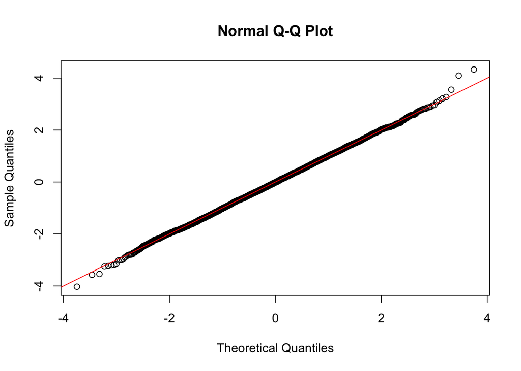

```r
# Check model output - residuals TEST
qqnorm(residuals(ocean_spp)[which(residuals(ocean_spp) < 10000)])
abline(c(0, 1), col = "red")
```

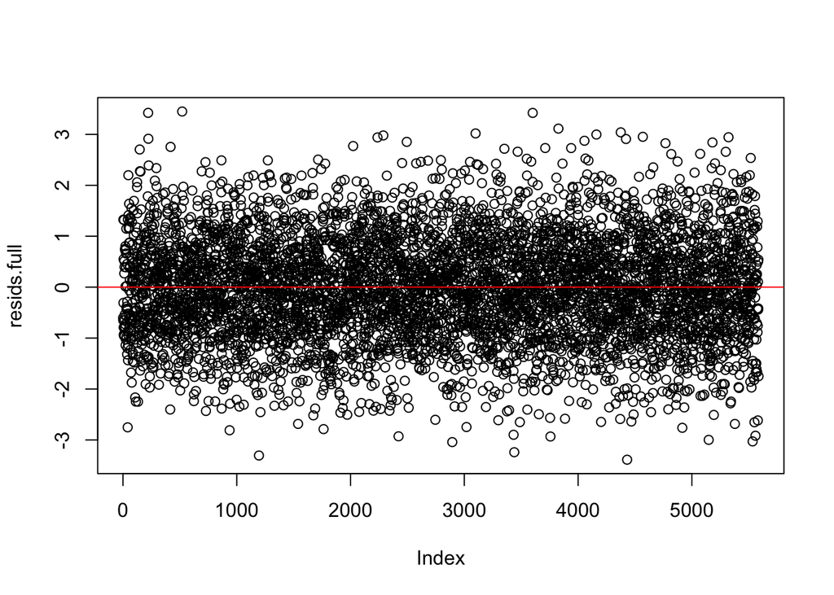

```r
# omit non-finite residuals FULL MODEL
resids.full = residuals(ocean_spp)[is.finite((residuals(ocean_spp)))]
plot(resids.full)
abline(c(0, 0), col = "red")
```

### Trait guild model

**MANYGLM Clusters - Ocean Basin**

Trait (cluster)*Env (ocean basin) - Manyglm

```r
ocean_clusters_many <- traitglm(L = alb_prey_pa_use_mv,
                                R = alb_covars_use$OceanBasin,
                                Q = traits_use$cluster,
                                family = binomial(link = "logit"),
                                composition = TRUE
                                )
#note default is "manyglm"
#note that col.intercepts = TRUE is the default
ocean_clusters_many
saveRDS(ocean_clusters_many, file = here::here("outputs_figures/5_traitglms/ocean_models_PA/ocean_clusters_many.rds"))
```

```r
#ocean_clusters_many$deviance
an_ocean_clusters_many = anova(ocean_clusters_many, test = "LR", nBoot = 100)
an_ocean_clusters_many
saveRDS(an_ocean_clusters_many, file = here::here("outputs_figures/5_traitglms/ocean_models_PA/ocean_clusters_many_anova.rds"))

#ocean_ocean_clusters_sum = summary(ocean_clusters_many, nBoot=10)
#ocean_ocean_clusters_sum
#saveRDS(ocean_ocean_clusters_sum, file = here::here("outputs_figures/5_traitglms/ocean_models_PA/ocean_clusters_many_summary.rds"))
```

```r
ocean_clusters_many
```

```
##
## Call:  traitglm(L = alb_prey_pa_use_mv, R = alb_covars_use$OceanBasin,      Q = traits_use$cluster, family = binomial(link = "logit"),      composition = TRUE)
## [1] "binomial(link=logit)"
##
## Degrees of Freedom: 5585 Total (i.e. Null); 5420 Residual
##
##                     l
## 2*log-likelihood:   -2937
## Residual Deviance:   2937
## AIC:                 3269
```

```r
an_ocean_clusters_many
```

```
## Analysis of Deviance Table
##
## Model  1: traitglm(L = alb_prey_pa_use_mv, R = alb_covars_use$OceanBasin,     Q = traits_use$cluster, family = binomial(link = "logit"),     composition = TRUE, get.fourth = FALSE)
## Model  2: traitglm(L = alb_prey_pa_use_mv, R = alb_covars_use$OceanBasin,     Q = traits_use$cluster, family = binomial(link = "logit"),     composition = TRUE)
##
## Multivariate test:
##                           Res.Df Df.diff   Dev Pr(>Dev)
## Main effects only           5432
## env:trait (fourth corner)   5420      12 75.38     0.01 **
## ---
## Signif. codes:  0 '***' 0.001 '**' 0.01 '*' 0.05 '.' 0.1 ' ' 1
## Arguments: P-value calculated using 100 iterations via PIT-trap block resampling.
```

```r
a        = max( abs(ocean_clusters_many$fourth.corner) )
colort   = colorRampPalette(c("blue","grey","red")) #can replace "grey" with "white"
temp = t(as.matrix(ocean_clusters_many$fourth.corner))

rownames(temp) = c(#"Mediterranean",
                   "N Atlantic",
                   "N Pacific"#, "S Pacific"
                   )

colnames(temp)
```

```
## [1] "X2" "X3" "X4" "X5" "X6" "X7"
```

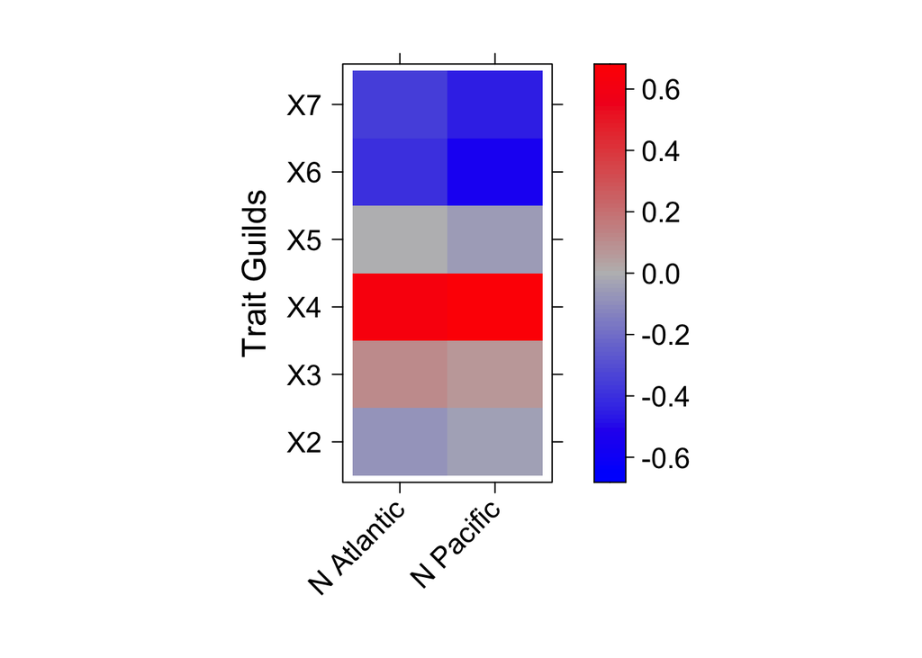

```r
ocean_clusters_many_graph = levelplot(temp,
                     xlab=list("", cex=1.5), #Ocean Basins
                     ylab=list("Trait Guilds", cex=1.5),
                     col.regions=colort(100),
                     at=seq(-a, a,length=100),
                     scales = list(x=list(rot = 45, cex=1.3), y=list(cex=1.3)),
                     colorkey=list(labels=list(cex=1.3)))

print(ocean_clusters_many_graph)
```

```r
ggsave(here::here("outputs_figures/5_traitglms/ocean_models_PA/ocean_clusters_many_graph.jpeg"),
       plot = as.ggplot(ocean_clusters_many_graph), width=12, height=12, dpi=300)
ggsave(here::here("outputs_figures/5_traitglms/ocean_models_PA/ocean_clusters_many_graph.pdf"),
       plot = as.ggplot(ocean_clusters_many_graph), width=12, height=12, dpi=300)
```

### Trait models

**MANYGLM Trait values - Ocean Basin**

Trait (trait matrix)*Env (ocean basin) - Manyglm

```r
ocean_trait_many <- traitglm(L = alb_prey_pa_use_mv,
                             R = alb_covars_use$OceanBasin,
                             Q = traits_use[,1:4],
                             family=binomial(link = "logit"),
                             composition = TRUE
                             )
#note default is "manyglm"
#note that col.intercepts = TRUE is the default
ocean_trait_many
saveRDS(ocean_trait_many, file = here::here("outputs_figures/5_traitglms/ocean_models_PA/ocean_traits_many.rds"))
```

```r
#ocean_trait_many$deviance
an_ocean_trait_many = anova(ocean_trait_many, test = "LR", nBoot = 100)
an_ocean_trait_many
saveRDS(an_ocean_trait_many, file = here::here("outputs_figures/5_traitglms/ocean_models_PA/ocean_traits_many_anova.rds"))

#ocean_ocean_trait_sum = summary(ocean_trait_many, nBoot=10)
#ocean_ocean_trait_sum
#saveRDS(ocean_ocean_trait_sum, file = here::here("outputs_figures/5_traitglms/ocean_models_PA/ocean_trait_many_summary.rds"))
```

```r
ocean_trait_many
```

```
##
## Call:  traitglm(L = alb_prey_pa_use_mv, R = alb_covars_use$OceanBasin,      Q = traits_use[, 1:4], family = binomial(link = "logit"),      composition = TRUE)
## [1] "binomial(link=logit)"
##
## Degrees of Freedom: 5585 Total (i.e. Null); 5420 Residual
##
##                     l
## 2*log-likelihood:   -2921
## Residual Deviance:   2921
## AIC:                 3253
```

```r
an_ocean_trait_many
```

```
## Analysis of Deviance Table
##
## Model  1: traitglm(L = alb_prey_pa_use_mv, R = alb_covars_use$OceanBasin,     Q = traits_use[, 1:4], family = binomial(link = "logit"),     composition = TRUE, get.fourth = FALSE)
## Model  2: traitglm(L = alb_prey_pa_use_mv, R = alb_covars_use$OceanBasin,     Q = traits_use[, 1:4], family = binomial(link = "logit"),     composition = TRUE)
##
## Multivariate test:
##                           Res.Df Df.diff   Dev Pr(>Dev)
## Main effects only           5432
## env:trait (fourth corner)   5420      12 91.32     0.01 **
## ---
## Signif. codes:  0 '***' 0.001 '**' 0.01 '*' 0.05 '.' 0.1 ' ' 1
## Arguments: P-value calculated using 100 iterations via PIT-trap block resampling.
```

```r
a        = max( abs(ocean_trait_many$fourth.corner) )
colort   = colorRampPalette(c("blue","grey","red")) #can replace "grey" with "white"
temp = t(as.matrix(ocean_trait_many$fourth.corner))

rownames(temp) = c(#"Mediterranean",
                   "N Atlantic",
                   "N Pacific"#,
                   #"S Pacific"
                   )

colnames(temp)
```

```
## [1] "vert_habitatepipelagic"        "vert_habitatmesopelagic"
## [3] "horz_habitatcontinental shelf" "horz_habitatoceanic"
## [5] "diel_migrant_catdiel (yes)"    "season_catseason (yes)"
```

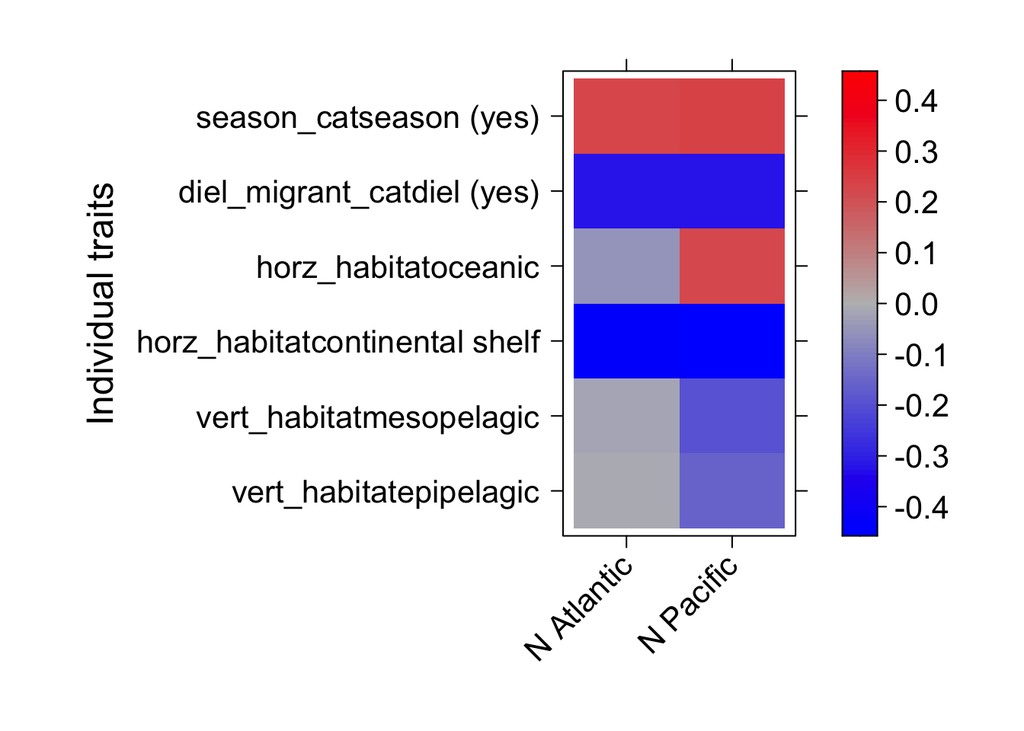

```r
ocean_trait_many_graph = levelplot(temp,
                     xlab=list("", cex=1.5), #Ocean Basins
                     ylab=list("Individual traits", cex=1.5),
                     col.regions=colort(100),
                     at=seq(-a, a,length=100),
                     scales = list(x=list(rot = 45, cex=1.3), y=list(cex=1.3)),
                     colorkey=list(labels=list(cex=1.3)))


print(ocean_trait_many_graph)
```

```r
ggsave(here::here("outputs_figures/5_traitglms/ocean_models_PA/ocean_traits_many_graph.pdf"),
       plot = as.ggplot(ocean_trait_many_graph), width=12, height=12, dpi=300)
ggsave(here::here("outputs_figures/5_traitglms/ocean_models_PA/ocean_traits_many_graph.jpeg"),
       plot = as.ggplot(ocean_trait_many_graph), width=12, height=12, dpi=300)
```

### Full model

**MANYGLM Speceis + Trait values - Ocean Basin**

```r
ocean_full_many <- traitglm(L = alb_prey_pa_use_mv,
                            R = alb_covars_use$OceanBasin,
                            Q = alb_trait_use[,c(1,4:7)],
                            family=binomial(link = "logit")#,
                            #composition = TRUE
                            )
ocean_full_many
saveRDS(ocean_full_many, here::here("outputs_figures/5_traitglms/ocean_models_PA/ocean_full_spp_many.rds"))
```

```r
an_ocean_full_many = anova(ocean_full_many, nBoot = 100)
an_ocean_full_many
saveRDS(an_ocean_full_many, here::here("outputs_figures/5_traitglms/ocean_models_PA/ocean_full_spp_many_anova.rds"))

#ocean_full_spp_sum = summary(ocean_full_many, nBoot=10)
#ocean_full_spp_sum
```

### Model comparison

```r
an_ocean_spp
```

```
## Analysis of Deviance Table
##
## Model  1: traitglm(L = alb_prey_pa_use_mv, R = alb_covars_use$OceanBasin,     family = binomial(link = "logit"), get.fourth = FALSE)
## Model  2: traitglm(L = alb_prey_pa_use_mv, R = alb_covars_use$OceanBasin,     family = binomial(link = "logit"))
##
## Multivariate test:
##                           Res.Df Df.diff   Dev Pr(>Dev)
## Main effects only           5486
## env:trait (fourth corner)   5292     194 77.69    0.604
## Arguments: P-value calculated using 100 iterations via PIT-trap block resampling.
```

```r
an_ocean_clusters_many
```

```
## Analysis of Deviance Table
##
## Model  1: traitglm(L = alb_prey_pa_use_mv, R = alb_covars_use$OceanBasin,     Q = traits_use$cluster, family = binomial(link = "logit"),     composition = TRUE, get.fourth = FALSE)
## Model  2: traitglm(L = alb_prey_pa_use_mv, R = alb_covars_use$OceanBasin,     Q = traits_use$cluster, family = binomial(link = "logit"),     composition = TRUE)
##
## Multivariate test:
##                           Res.Df Df.diff   Dev Pr(>Dev)
## Main effects only           5432
## env:trait (fourth corner)   5420      12 75.38     0.01 **
## ---
## Signif. codes:  0 '***' 0.001 '**' 0.01 '*' 0.05 '.' 0.1 ' ' 1
## Arguments: P-value calculated using 100 iterations via PIT-trap block resampling.
```

```r
an_ocean_trait_many
```

```
## Analysis of Deviance Table
##
## Model  1: traitglm(L = alb_prey_pa_use_mv, R = alb_covars_use$OceanBasin,     Q = traits_use[, 1:4], family = binomial(link = "logit"),     composition = TRUE, get.fourth = FALSE)
## Model  2: traitglm(L = alb_prey_pa_use_mv, R = alb_covars_use$OceanBasin,     Q = traits_use[, 1:4], family = binomial(link = "logit"),     composition = TRUE)
##
## Multivariate test:
##                           Res.Df Df.diff   Dev Pr(>Dev)
## Main effects only           5432
## env:trait (fourth corner)   5420      12 91.32     0.01 **
## ---
## Signif. codes:  0 '***' 0.001 '**' 0.01 '*' 0.05 '.' 0.1 ' ' 1
## Arguments: P-value calculated using 100 iterations via PIT-trap block resampling.
```

## TRAIT GLMS - LASSO

### Read in models

```r
#Manyglm
ocean_spp_LASSO = readRDS(here::here("outputs_figures/5_traitglms/ocean_models_PA/ocean_spp_LASSO.rds"))
ocean_cluster_LASSO = readRDS(here::here("outputs_figures/5_traitglms/ocean_models_PA/ocean_clusters_LASSO.rds"))
ocean_trait_LASSO = readRDS(here::here("outputs_figures/5_traitglms/ocean_models_PA/ocean_traits_LASSO.rds"))
ocean_phylo_LASSO = readRDS(here::here("outputs_figures/5_traitglms/ocean_models_PA/ocean_phylo_LASSO.rds"))
```

### Species traitglm LASSO

**SPP LASSO - Ocean Basin**

```r
ocean_spp_LASSO <- traitglm(L = alb_prey_pa_use_mv,
                      R = alb_covars_use$OceanBasin,
                      family = binomial(link = "logit"),
                      method = "glm1path"#,
                      #composition = TRUE
                      )
saveRDS(ocean_spp_LASSO, here::here("outputs_figures/5_traitglms/ocean_models_PA/ocean_spp_LASSO.rds"))
#note default is "manyglm"
#note that col.intercepts = TRUE is the default
```

### Trait guild tratglm LASSO

**GLM1PATH Clusters - Ocean Basin**

Using method = glm1path == LASSO model.

```r
ocean_cluster_LASSO <- traitglm(L = alb_prey_pa_use_mv,
                                R = alb_covars_use$OceanBasin,
                                Q = traits_use$cluster,
                                family=binomial(link = "logit"),
                                method="glm1path",
                                composition = TRUE
                                )
saveRDS(ocean_cluster_LASSO, here::here("outputs_figures/5_traitglms/ocean_models_PA/ocean_clusters_LASSO.rds"))
#note default is "manyglm"
#note that col.intercepts = TRUE is the default
```

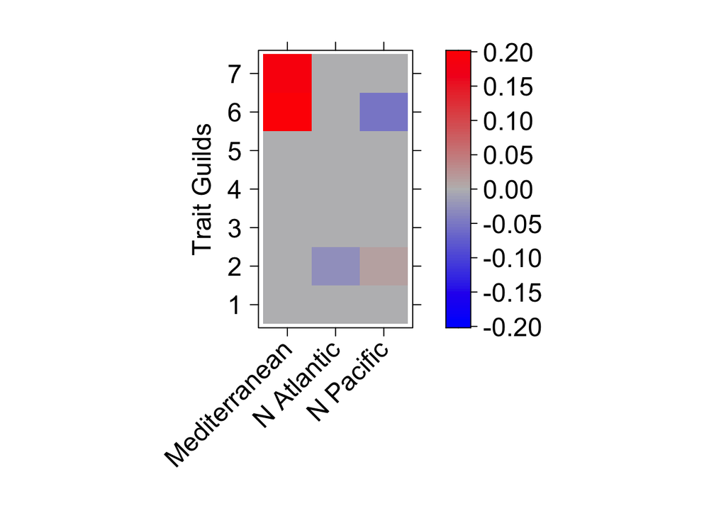

```r
a        = max( abs(ocean_cluster_LASSO$fourth.corner) )
colort   = colorRampPalette(c("blue","grey","red")) #can replace "grey" with "white"
temp = t(as.matrix(ocean_cluster_LASSO$fourth.corner))

rownames(temp) = c("Mediterranean",
                   "N Atlantic",
                   "N Pacific"#,
                   #"S Pacific"
                   )

colnames(temp) = c("1",
                   "2",
                   "3",
                   "4",
                   "5",
                   "6",
                   "7")

ocean_cluster_LASSO_graph = levelplot(temp,
                     xlab=list("", cex=1.5), #Ocean Basins
                     ylab=list("Trait Guilds", cex=1.5),
                     col.regions=colort(100),
                     at=seq(-a, a,length=100),
                     scales = list(x=list(rot = 45, cex=1.5), y=list(cex=1.5)),
                     colorkey=list(labels=list(cex=1.5)))

print(ocean_cluster_LASSO_graph)
```

```r
ggsave(here::here("outputs_figures/5_traitglms/ocean_models_PA/ocean_clusters_LASSO_graph.jpeg"),
       plot = as.ggplot(ocean_cluster_LASSO_graph), width=8, height=8, dpi=300)
ggsave(here::here("outputs_figures/5_traitglms/ocean_models_PA/ocean_clusters_LASSO_graph.pdf"),
       plot = as.ggplot(ocean_cluster_LASSO_graph), width=8, height=8, dpi=300)
```

### Trait information traitglm LASSO

*GLM1PATH Trait values - Ocean Basin**

Using method = glm1path == LASSO model.

```r
ocean_trait_LASSO <- traitglm(L = alb_prey_pa_use_mv,
                              R = alb_covars_use$OceanBasin,
                              Q = traits_use[,1:4], #traits_use[,1:5]
                              family=binomial(link = "logit"),
                              method="glm1path",
                              composition = TRUE
                              )
saveRDS(ocean_trait_LASSO, here::here("outputs_figures/5_traitglms/ocean_models_PA/ocean_traits_LASSO.rds"))
#note default is "manyglm"
#note that col.intercepts = TRUE is the default
```

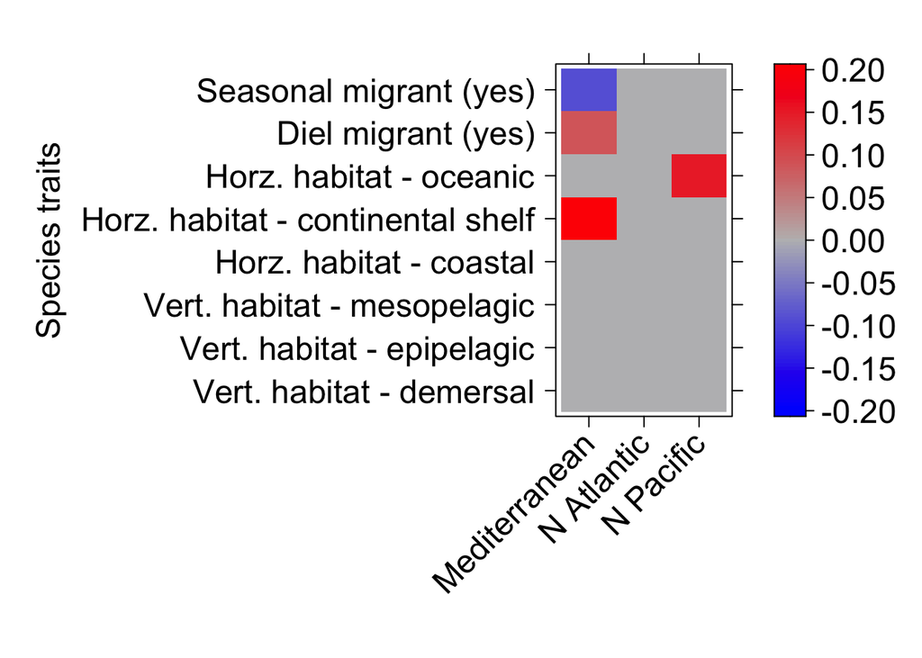

```r
a        = max( abs(ocean_trait_LASSO$fourth.corner) )
colort   = colorRampPalette(c("blue","grey","red")) #can replace "grey" with "white"
temp = t(as.matrix(ocean_trait_LASSO$fourth.corner))

rownames(temp) = c("Mediterranean",
                   "N Atlantic",
                   "N Pacific"#,
                   #"S Pacific"
                   )

colnames(temp) = c("Vert. habitat - demersal",
                   "Vert. habitat - epipelagic",
                   "Vert. habitat - mesopelagic",
                   "Horz. habitat - coastal",
                   "Horz. habitat - continental shelf",
                   "Horz. habitat - oceanic",
                   "Diel migrant (yes)",
                   "Seasonal migrant (yes)") #,
                   #"Gregarious - schooling"

ocean_LASSO_graph = levelplot(temp,
                     xlab=list("", cex=1.5), #Ocean Basins
                     ylab=list("Species traits", cex=1.5),
                     col.regions=colort(100),
                     at=seq(-a, a,length=100),
                     scales = list(x=list(rot = 45, cex=1.5), y=list(cex=1.5)),
                     colorkey=list(labels=list(cex=1.5)))

print(ocean_LASSO_graph)
```

```r
ggsave(here::here("outputs_figures/5_traitglms/ocean_models_PA/ocean_traits_LASSO_graph.pdf"),
       plot = as.ggplot(ocean_LASSO_graph), width=12, height=8, dpi=300)
ggsave(here::here("outputs_figures/5_traitglms/ocean_models_PA/ocean_traits_LASSO_graph.jpeg"),
       plot = as.ggplot(ocean_LASSO_graph), width=12, height=8, dpi=300)
```

### Phylo for Supp Info

**GLM1PATH Phylo - Ocean Basin**

Using method = glm1path == LASSO model.

```r
ocean_phylo_LASSO <- traitglm(L = alb_prey_pa_use_mv,
                                R = alb_covars_use$OceanBasin,
                                Q = alb_trait_use$prey_order,
                                family=binomial(link = "logit"),
                                method="glm1path",
                                composition = TRUE
                                )
saveRDS(ocean_phylo_LASSO, file = here::here("outputs_figures/5_traitglms/ocean_models_PA/ocean_phylo_LASSO.rds"))
```

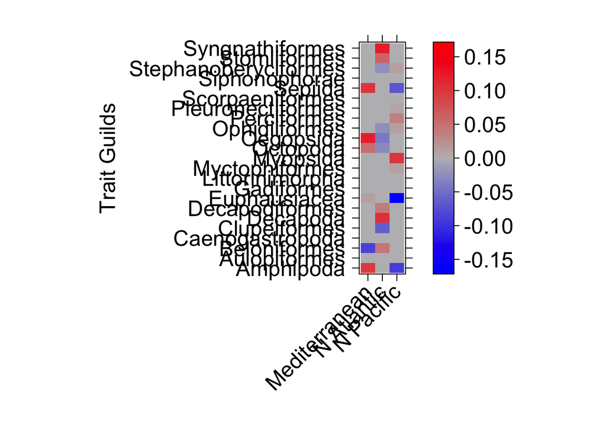

```r
a        = max( abs(ocean_phylo_LASSO$fourth.corner) )
colort   = colorRampPalette(c("blue","grey","red")) #can replace "grey" with "white"
temp = t(as.matrix(ocean_phylo_LASSO$fourth.corner))

rownames(temp) = c("Mediterranean",
                   "N Atlantic",
                   "N Pacific"
                   )

colnames(temp) = c("Amphipoda", "Aulopiformes", "Beloniformes", "Caenogastropoda", "Clupeiformes", "Decapoda", "Decapodiformes",
                   "Euphausiacea", "Gadiformes", "Littorinimorpha", "Myctophiformes", "Myopsida", "Octopoda", "Oegopsida",
                   "Ophidiiformes", "Perciformes", "Pleuronectiformes", "Scorpaeniformes", "Sepiida", "Siphonophorae", "Stephanoberyciformes",
                   "Stomiiformes", "Syngnathiformes")

ocean_phylo_LASSO_graph = levelplot(temp,
                     xlab=list("", cex=1.5), #Ocean Basins
                     ylab=list("Trait Guilds", cex=1.5),
                     col.regions=colort(100),
                     at=seq(-a, a,length=100),
                     scales = list(x=list(rot = 45, cex=1.5), y=list(cex=1.5)),
                     colorkey=list(labels=list(cex=1.5)))

print(ocean_phylo_LASSO_graph)
```

```r
ggsave(here::here("outputs_figures/5_traitglms/ocean_models_PA/ocean_phylo_LASSO_graph.jpeg"),
       plot = as.ggplot(ocean_phylo_LASSO_graph), width=8, height=12, dpi=300)
ggsave(here::here("outputs_figures/5_traitglms/ocean_models_PA/ocean_phylo_LASSO_graph.pdf"),
       plot = as.ggplot(ocean_phylo_LASSO_graph), width=8, height=12, dpi=300)
```